# 10-Tarea

Mario Becerra

Abril 2015

Basado en el trabajo de Andreu Boada de Atela (andreuboadadeatela@gmail.com).

# Ejercicio 1

Implementar el algoritmo EM para mezclas de normales en el caso univariado.

Modelo de mezcla de dos normales. Consideremos los siguientes datos:

```
## stat_bin: binwidth defaulted to range/30. Use 'binwidth = x' to adjust this.
```

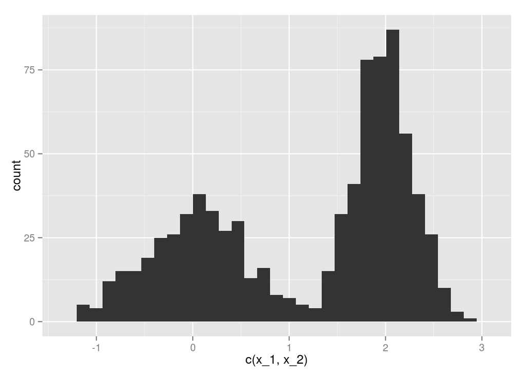

```r
set.seed(280572)
N <- 800
n <- sum(rbinom(N, 1, 0.6))

x_1 <- rnorm(N - n, 0, 0.5)
x_2 <- rnorm(n, 2, 0.3)
qplot(c(x_1, x_2))
```

Estos datos tienen una estructura bimodal. Es poco apropiado modelar estos datos con un modelo normal $(\mu,\sigma^2)$.

Podemos entonces modelar pensando que los datos vienen de dos clases, cada una con una distribución normal pero con distintos parámetros. ¿Cómo ajustaríamos tal modelo?

La variable aleatoria $X$ es una mezcla de normales si $p(x)=\sum_{k=1}^K \pi_k \phi_{\theta_k}(x)$ donde $\phi_{\theta_k}$ es una densidad normal con parámetros $\theta_k=(\mu_k, \sigma_k)$ y los ponderadores de la mezcla $\pi_k$ satisfacen $\sum_i \pi_i = 1$

Ahora, si vemos la mezcla Gaussiana desde la representación generativa, o formulación en variable latente, tenemos el modelo gráfico $\Delta$ -> $X$ donde $\Delta$ es una indicadora de clase. En el caso del modelo de dos clases tenemos $\delta \in \{0,1\}$ y sea $P(\delta=1)=\pi$, escribimos la conjunta $p(\delta, x)=\pi^{\delta}(1-\pi)^{1-\delta}[\delta\phi_{\theta_1}(x)+(1-\delta)\phi_{\theta_2}(x)]$

y podemos verificar que la distribución marginal es una mezcla gaussiana: $p(x)\sum_{\delta}p(x|\delta)p(\delta)$ $=\phi_{\theta_1}(x) \pi + \phi_{\theta_2}(x)(1-\pi)$

Ahora, si conociéramos la clase a la que pertenece cada observación ($\delta^i$) podríamos escribir la log-verosimilitud completa (sin censura) como $\sum_{i=1}^N \log(\delta^i \phi_{\theta_1} (x^i)+ (1-\delta^i)\phi_{\theta_2}(x^i)) + \delta^i \log\pi + (1-\delta^i)\log(1-\pi).$

Aquí, es fácil ver que la verosimilitud se separa en dos partes, una para $\delta^i=1$ y otra para $\delta^i=0$, y los estimadores de máxima verosimilitud son entonces:

$\hat{\mu}_1=\frac{\sum_i\delta^i x^i}{\sum_i (\delta^i)}$ $\hat{\mu}_2=\frac{\sum_i(1-\delta^i) x^i}{\sum_i (1-\delta^i)}$

$\hat{\sigma}_1^2=\frac{\sum_i\delta^i (x^i-\mu_1)^2}{\sum_i (\delta^i)}$ $\hat{\sigma}_2^2=\frac{\sum_i(1-\delta^i) (x^i-\mu_2)^2}{\sum_i (1-\delta^i)},$

y $\hat{\pi}$ es la proporción de casos tipo 1 en los datos. Este problema es entonces trivial de resolver.

En el caso de variables latentes $\delta^i$ están censuradas y tenemos que marginalizar con respecto a $\delta^i$, resultando en:

$\sum_{i=1}^N \log(\pi \phi_{\theta_1} (x^i)+ (1-\pi)\phi_{\theta_2}(x^i)).$

donde $\pi$ es la probabilidad de que la observación venga de la primera densidad. Este problema es más difícil pues tenemos tanto $\pi$ como $\theta_1$ y $\theta_2$ dentro del logaritmo. Podemos resolver numéricamente como sigue con la funcion *optim* de R:

```r
crearLogLike <- function(x){
  logLike <- function(theta){
    pi <- exp(theta[1]) / (1 + exp(theta[1]))
    mu_1 <- theta[2]
    mu_2 <- theta[3]
    sigma_1 <- exp(theta[4])
    sigma_2 <- exp(theta[5])
    sum(log(pi*dnorm(x, mu_1, sd=sigma_1)+(1-pi)*dnorm(x,mu_2,sd=sigma_2)))
  }
  logLike
}
x <- c(x_1,x_2)
loglik <- crearLogLike(x)
system.time(salida <- optim(c(0.5,0,0,1,1),
                            loglik, control = list(fnscale=-1)))
```

```
##    user  system elapsed
##   0.136   0.000   0.143
```

```r
exp(salida$par[1]) / (1 + exp(salida$par[1]))
```

```
## [1] 0.5857
```

```r
salida$par[2:3]
```

```
## [1] 1.98759 0.03046
```

```r
exp(salida$par[4:5])
```

```
## [1] 0.2977 0.5160
```

Implementando ahora el algoritmo de Esperanza Maximización.

```r
em <- function(theta, x){
  # Entrada: theta.gorro y datos
  # Salida: función de theta (esperada)
  n <- length(x)
  gamma <- mat.or.vec(n,1) # inicializar vector de gammas
  for(i in 1:n){ # estimacion de gammas
    aux <- theta[5] * dnorm(x[i],theta[1],sqrt(theta[3]))
    aux2 <- (1-theta[5])*dnorm(x[i],theta[2],sqrt(theta[4]))
    gamma[i] <- aux / (aux + aux2)
  }

  # Se evalua la verosimilitud
  vec <- mat.or.vec(n,1)
  for(i in 1:n){
    vec[i] <- log(theta[5]*dnorm(x[i],theta[1],sqrt(theta[3]))  + (1 - theta[5])*dnorm(x[i],theta[2],sqrt(theta[4])))
  }
  fun_eval0 <- sum(vec)

  # Estimacion de pi (pi^hat)
  theta[5] <- (1/n)*sum(gamma)
  # Estimacion de mu_1 (mu_1^hat)
  theta[1] <- (sum(gamma*x))/(sum(gamma))
  # Estimacion de mu_2 (mu_2^hat)
  theta[2] <- (sum((1-gamma)*x))/(sum(1-gamma))
  # Estimacion de sigma_1^2
  theta[3] <- (sum(gamma*(x-theta[1])^2))/(sum(gamma))
  # Estimacion de sigma_2^2
  theta[4] <- (sum((1-gamma)*(x-theta[2])^2))/(sum(1-gamma))

  # Evalua verosimilitud
  vec <- mat.or.vec(n,1)
  for(i in 1:n){
    vec[i] <- log(theta[5]*dnorm(x[i],theta[1],sqrt(theta[3]))  + (1 - theta[5])*dnorm(x[i],theta[2],sqrt(theta[4])))
  }
  fun_eval <- sum(vec)

  # convergencia
  while(abs(fun_eval - fun_eval0) > 1e-6){
    for(i in 1:n){ # estimacion de gammas
      aux <- theta[5] * dnorm(x[i],theta[1],sqrt(theta[3]))
      aux2 <- (1-theta[5])*dnorm(x[i],theta[2],sqrt(theta[4]))
      gamma[i] <- aux / (aux + aux2)
    }
    theta[5] <- (1/n)*sum(gamma) # pi
    theta[1] <- (sum(gamma*x))/(sum(gamma)) # mu_1
    theta[2] <- (sum((1-gamma)*x))/(sum(1-gamma)) # mu_2
    theta[3] <- (sum(gamma*(x-theta[1])^2))/(sum(gamma)) # sigma_1
    theta[4] <- (sum((1-gamma)*(x-theta[2])^2))/(sum(1-gamma)) # sigma_2

    # Evaluacion de verosimilitud
    vec <- mat.or.vec(n,1)
    for(i in 1:n){
      vec[i] <- log(theta[5]*dnorm(x[i],theta[1],sqrt(theta[3]))  + (1 - theta[5])*dnorm(x[i],theta[2],sqrt(theta[4])))
    }
    fun_eval0 <- fun_eval
    fun_eval <- sum(vec)
  }
  return (theta)
}

theta <- c(0.5,3,1,1,0.5)
system.time(theta.n <- em(theta,x))
```

```
##    user  system elapsed
##   0.393   0.008   0.405
```

```r
# pi = 0.3
theta.n[5]
```

```
## [1] 0.4144
```

```r
# mu_1 = 0
theta.n[1]
```

```
## [1] 0.03074
```

```r
# mu_2 = 2
theta.n[2]
```

```
## [1] 1.988
```

```r
# sigma_1 = 1
sqrt(theta.n[3])
```

```
## [1] 0.5159
```

```r
# sigma_2 = 0.5
sqrt(theta.n[4])
```

```
## [1] 0.2978
```

# Ejercicio 2

Realizar conglomerados usando los datos HELP.

Utilizaremos las siguientes variables de los datos HELP: en la calle o refugio los últimos 180 días (*homeless*), puntaje CESD mayor a 20, recibió tratamiento por abuso de sustancias (satreat), ligado a cuidados primarios (*linkstatus*). Crea conglomerados usando poLCA.

Lectura de datos:

```r
library(poLCA)
help <- read.csv('help.csv')
```

```r
table(help$homeless)
```

```
##
##   0   1
## 244 209
```

```r
help$cesd20 <- 1*(help$cesd > 20)
table(help$cesd20)
```

```
##
##   0   1
##  80 373
```

Recibió tratamiento por abuso de sustancias:

```r
table(help$satreat)
```

```
##
##   0   1
## 324 129
```

Ligado a ciudadanos primarios:

```r
table(help$linkstatus)
```

```
##
##   0   1
## 268 163
```

El objetivo es crear conglomerados a partir de estas 4 variables:

```r
f <- cbind(homeless, cesd20, satreat, linkstatus) ~ 1
tabla <- dplyr::select(help,homeless,cesd20,satreat,linkstatus)
tabla <- tabla[complete.cases(tabla),]
tabla <- tabla %>%
  dplyr::mutate_each(funs(factor)) %>%
  data.frame
str(tabla)
```

```
## 'data.frame':    431 obs. of  4 variables:
##  $ homeless  : Factor w/ 2 levels "0","1": 1 1 1 2 1 1 2 2 2 1 ...
##  $ cesd20    : Factor w/ 2 levels "0","1": 2 2 1 2 1 2 2 2 2 2 ...
##  $ satreat   : Factor w/ 2 levels "0","1": 1 1 2 1 1 2 2 1 2 1 ...
##  $ linkstatus: Factor w/ 2 levels "0","1": 2 1 1 2 1 1 1 1 1 1 ...
```

Modelo:

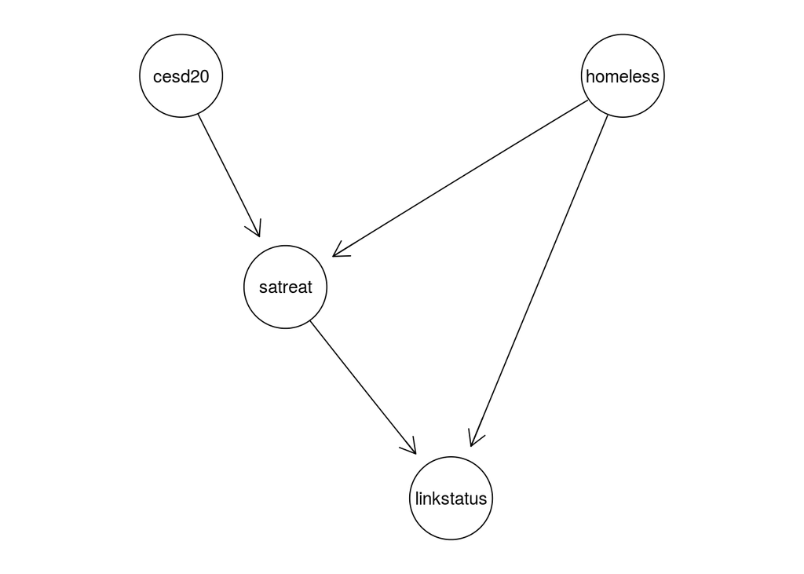

```r
net_obs <- hc(tabla,  score='aic')
graphviz.plot(net_obs)
```

```r
mod <- poLCA(f, tabla, nclass = 3, verbose = FALSE)
mod$aic
```

```
## [1] 2094
```

```r
tabla$pred_class <- factor(mod$predclass)
str(tabla)
```

```
## 'data.frame':    431 obs. of  5 variables:
##  $ homeless  : Factor w/ 2 levels "0","1": 1 1 1 2 1 1 2 2 2 1 ...
##  $ cesd20    : Factor w/ 2 levels "0","1": 2 2 1 2 1 2 2 2 2 2 ...
##  $ satreat   : Factor w/ 2 levels "0","1": 1 1 2 1 1 2 2 1 2 1 ...
##  $ linkstatus: Factor w/ 2 levels "0","1": 2 1 1 2 1 1 1 1 1 1 ...
##  $ pred_class: Factor w/ 3 levels "1","2","3": 1 1 3 2 1 3 2 2 2 1 ...
```

Modelo de clases latentes:

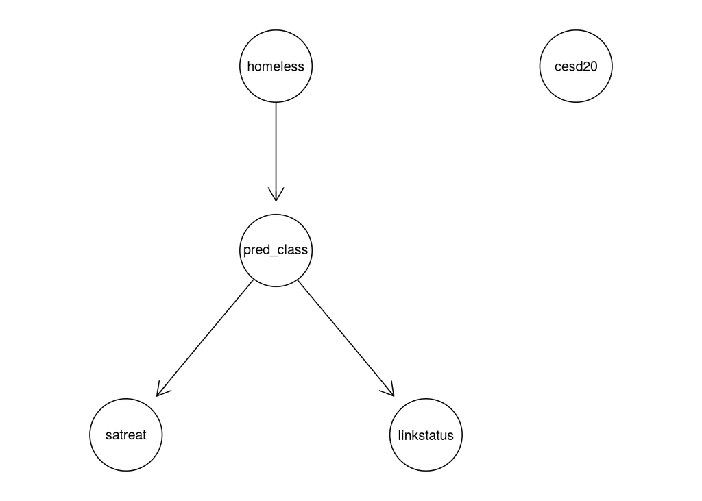

```r
net_obs_clases <- hc(tabla,  score='bic')
graphviz.plot(net_obs_clases)
```